# Modèle linéaire

Séance 2 - Régression linéaire multiple

Florent Chuffart & Magali Richard

24 Janvier 2019

## Evaluation

- individuelle sur un jeu de données aprés 4 séances de cours
- data challenge à la fin des séances

## Pré-requis

- R https://cran.r-project.org
- RStudio https://www.rstudio.com

## Cours

- https://github.com/magrichard/cours_modlin_M1

# Organisation prévisionnelle

Séance 1 - 3h (10/01) Régression linéaire simple

Séance 2 - 3h (24/01) Régression linéaire multiple

Séance 3 - 3h (31/01) Anova 1 facteur / partie A

Séance 4 - 3h (14/02) Anova 1 facteur / partie B

Séance 5 - 3h (21/02) Anova 2 facteurs

Séance 6 - 3h (07/03) Anova multiple

Séance 7 - 3h (11/03) Anova facteurs emboités

Séance 8 - 3h (14/03) Ancova

# Plan séance 2

## Régression linéaire multiple

1. Introduction et rappels
2. Présentation du modèle
3. Estimation (méthode des moindres carrés)
4. Décomposition de la variance
5. Test statistique et IC
6. Sélection de variables

## I. Introduction

### Rappels regression linéaire simple

**Objectif de la regression linéaire simple**: considérons $x$ et $Y$ deux variables. Y est expliquée (modélisée) par la variable explicative $x$.

Modèle :
$$E(Y) = f(x) = \beta_0 + \beta_1 x$$

*la méthode des moindres carrés ordinaires (MCO)*:

$$EQM(\beta_0, \beta_1) = \sum^{n}_{i=1} (Y_i - \widehat\beta_0 - \widehat\beta_1x_i)^2$$

Soit
$$\sum(Y_i - \overline{Y}_n)^2 = \sum(\widehat{Y}_i - \overline{Y}_n)^2 + \sum(Y_i - \widehat{Y}_i)^2$$
$$SC_{tot} = SC_{reg} + SC_{res}$$

avec $\widehat{Y}_i$ la valeur estimée par le modèle pour $i=1,...,n$ et $\overline{Y}_n$ la moyenne empirique des observations sur $n$.

```r
d = read.table("data/data_nutri.csv", header=TRUE, sep=",", row.names = 1)
d$sex = as.factor(d$sex)
layout(1, respect=TRUE)
plot(d$taille, d$poids, main="poids~taille")
## Model
# Y~X
# E(Y) = b.X
# E(Y) = b_0 + b_1.X
# Y_i = b_0 + b_1.X_i + e_i
m = lm(d$poids~d$taille)
m$coefficients
```

```
## (Intercept)    d$taille
## -71.7196398   0.8428994
```

```r
abline(a=m$coefficients[[1]], b=m$coefficients[[2]], col=2) # /!\ y = b.x + a
# residuals
m$residuals
```

[output not shown]

[output cut: 37 more lines]

[output not shown]

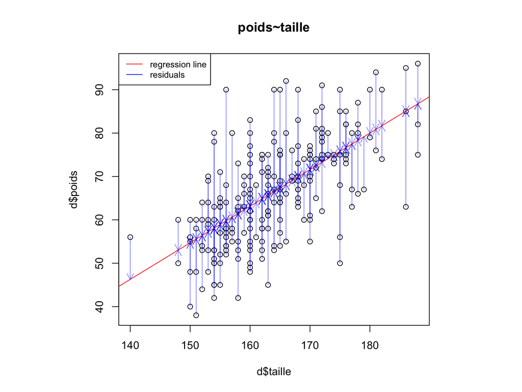

```r
suppressWarnings(arrows(d$taille, d$poids, d$taille, d$poids-m$residuals, col=adjustcolor(4, alpha.f=0.5), length=0.1))
legend("topleft",c("regression line", "residuals"), col=c(2,4), lty=1, cex=.8)
```

## I. Introduction

**Objectif de la regression linéaire multiple**: chercher une relation entre la variable observée $Y$ et plusieurs variables explicative $X_1, ..., X_p$.

## II. Présentation du modèle

**Objectif de la regression linéaire multiple**: chercher une relation entre la variable observée $Y$ et plusieurs variables explicative $X_1, ..., X_p$.

Y est expliquée (modélisée) par les variables explicatives $X_1, ..., X_p$.

On applique alors le modèle linéaire suivant:

$$Y = \beta_0 + \beta_1X_1 + ... + \beta_pX_p + \epsilon$$

En pratique:

Dans un échantillon de $n$ individus, nous mesurons $y_i, x_{i,1},...,x_{i,p}$ pour $i=1,...,n$.

Les variables $x_{i,j}$ sont fixes, tandis que les variables $Y_i$ sont aléatoires.

## II. Présentation du modèle

### Exemple

```r
data(state)
stateEU <-  data.frame(state.x77, row.names=state.abb)
attach(stateEU)
```

Cette base de données comprend les mesures sur 50 pays des Etats-Unis de:

- Population: population estimée au 1er juillet 1975
- Income: revenu par individu (1974)
- Illiteracy: illettrisme (1970, pourcentage de la population)
- Life.Exp: espérance de vie moyenne (1969-1971)
- Murder: taux d’homicide pour 100 000 individus (1976)
- HS Grad: pourcentage de diplômés niveau baccalauréat –high-school graduates– (1970)
- Frost: nombre de jours moyens avec des températures inférieures à 0$^o$C dans les grandes villes (1931-1960)
- Area : surface du pays en miles carrés.

## II. Présentation du modèle

### Exemple

Représentation des donnée.

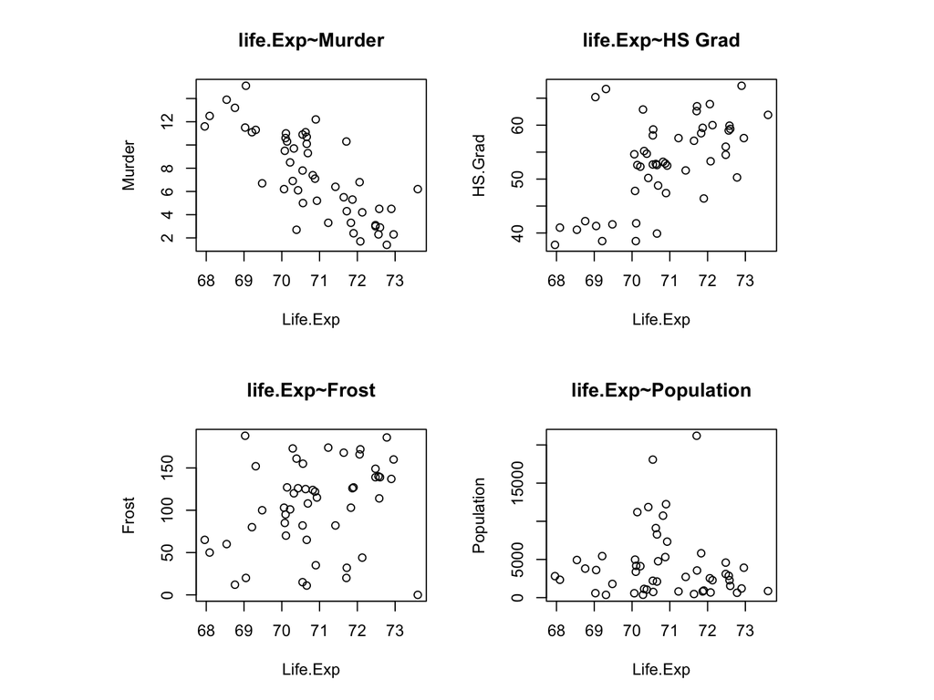

```r
# README RStudio config, uncheck: # preferences > R Markdown > show output inline for...
layout(matrix(1:4, 2, byrow=TRUE), respect=TRUE)
plot(Life.Exp, Murder, main="life.Exp~Murder")
plot(Life.Exp, HS.Grad, main="life.Exp~HS Grad")
plot(Life.Exp, Frost, main="life.Exp~Frost")
plot(Life.Exp, Population, main="life.Exp~Population")
```

## III. Estimation - Méthode des moindres carrés

### Méthode

Pour l’instant, la droite de régression est inconnue. Tout le problème est d’estimer les paramètres $\beta_0, ..., \beta_p$ du modèle de regression, à partir d’un échantillon de données.

Utiliser les **moindres carrés** revient à minimiser la quantité suivante:
$$min_{\beta_0, ...,\beta_p}\sum^n_{i=1}\Big(y_i -(\beta_0+ \beta_1X_1 + ... + \beta_pX_p)\Big)^2$$

## III. Estimation - Méthode des moindres carrés

### Version matricielle

Le système peut se réecrire

$$\left(\begin{array}
{rrr}
y_1\\
\vdots\\
y_n
\end{array}\right) = \left(\begin{array}
{rrr}
1 & x_{1,1} & ... & x_{1,p}\\
\vdots & \vdots & \vdots & \vdots \\
1 & x_{n,1} & ... & x_{n,p}
\end{array}\right) \left(\begin{array}
{rrr}
\beta_0\\
\vdots\\
\beta_n
\end{array}\right) + \left(\begin{array}
{rrr}
\epsilon_1\\
\vdots\\
\epsilon_n
\end{array}\right)$$

Avec $y = X\beta + \epsilon$

Et le vecteur des résidus $\widehat{e} = y - \widehat{y} = y - X\widehat\beta$

Les variables $y$ et $X$ sont mesurées tandis que l’estimateur $\beta$ est à déterminer. La **méthode des moindres carrés ordinaires** consiste à trouver le vecteur $\beta$ qui minimise $||\epsilon||^2 = {}^t{\epsilon}\epsilon$.

## III. Estimation - Méthode des moindres carrés

### Calcul

$$\begin{eqnarray}
||\epsilon||^2 & = & {}^t(y-X\widehat\beta) (y-X\widehat\beta) \\
& = & {}^tyy - {}^t\widehat\beta{}^tXy - {}^tyX\widehat\beta + {}^t\widehat\beta{}^tXX\widehat\beta \\
& = & {}^tyy - 2{}^t\widehat\beta^t(X)y - {}^t\widehat\beta{}^tXX\widehat\beta
\end{eqnarray}$$

car ${}^t\widehat\beta{}^tXy$ est un scalaire. Donc il est égal à sa transposée.

La dérivée par rapport à $\beta$ est alors égale à : $−2{}^tXy+2{}^tXX\widehat\beta$.

## III. Estimation - Méthode des moindres carrés

### Calcul

**Objectif** : Nous cherchons $\beta$ qui annule cette dérivée. Donc nous devons résoudre l’équation suivante :

$$^tXX\widehat\beta = {}^tXy$$
Nous trouvons après avoir inversé la matrice ${}^tXX$ (il faut naturellement vérifier que ${}^tXX$ est carrée et inversible c’est-à-dire qu’aucune des colonnes qui compose cette matrice ne soit proportionnelle aux autres colonnes)
$$\widehat\beta = ({}^t XX)^{-1}{}^{t} Xy.$$

## III. Estimation - Méthode des moindres carrés

### Application à la régression linéaire simple (p=2), pour info

$$\left(\begin{array}
{rrr}
{}^tXX
\end{array}\right) = \left(\begin{array}
{rrr}
n & \sum{x_i}\\
\sum{x_i} & \sum{x_i}^2
\end{array}\right) ; \left(\begin{array}
{rrr}
{}^tXy
\end{array}\right) = \left(\begin{array}
{rrr}
\sum{y_i}\\
\sum{x_iy_i}
\end{array}\right)$$

Donc

$$\left(\begin{array}
{rrr}
({}^tXX)^{-1}
\end{array}\right) = \frac{1}{n\sum{x_i^2 - (\sum{x_i^2})^2}}
\left(\begin{array}
{rrr}
\sum{x_i}^2 & -\sum{x_i}\\
-\sum{x_i} & n
\end{array}\right)
= \frac{1}{\sum{x_i - \overline{x}_n}}
\left(\begin{array}
{rrr}
\sum{x_i}^2/n & -\overline{x}_n\\
-\overline{x}_n & 1
\end{array}\right)$$

## III. Estimation

### Maximum de vraisemblance

La vraisemblance vaut
$$\mathcal{L}(Y,\beta,\sigma^2) = \Big(\frac{1}{\sqrt{2\pi\sigma^2}}\Big)^nexp\Big[\frac{1}{2\sigma^2}\sum^n_{i=1}(y_i-x'_i\beta)^2\Big]$$
$$\mathcal{L}(Y,\beta,\sigma^2) = \Big(\frac{1}{\sqrt{2\pi\sigma^2}}\Big)^nexp\Big[\frac{1}{2\sigma^2}||Y-X\beta||^2\Big]$$

D’où l’on déduit la log-vraisemblance

$$log\mathcal{L}(Y,\beta,\sigma^2) = \frac{n}{2}log(2\pi) -\frac{n}{2}log(\sigma^2) - \frac{1}{2\sigma^2}||Y-X\beta||^2$$
Pour maximiser la log-vraisemblance, il faut d’abord minimiser la quantité $||Y-X\beta||^2$, ce qui est justement le principe des moindres carrés ordinaires.

## IV. Analyse de la variance

### Variation expliquée et inexpliquée

La variation de $Y$ vient du fait de sa dépendance aux variables explicatives $X$. C’est la **variation expliquée par le modèle**.

Variation totale de Y = Variation expliquée par le modèle + Variation inexpliquée par le modèle

La méthode des moindres carrés conserve la décomposition (en variance expliquée et résiduelle) en considérenat la somme des carrés de ces différences:

$$\sum(y_i - \overline{y}_n)^2 = \sum(\widehat{y}_i - \overline{y}_n)^2 + \sum(y_i - \widehat{y}_i)^2$$
Soit
$$SC_{tot} = SC_{reg} + SC_{res}$$

Avec $SC_{tot}$ la somme des carrés totale, $SC_{reg}$ la somme des carrés due à la régression et $SC_{res}$ la somme des carrés des résidus.

## IV. Analyse de la variance

### Coefficient de determination $R^2$

La mesure du pourcentage de la variation totale expliquée par le modèle se fait par le **coefficient de détermination**.

$$R^2 = \frac{SC_{reg}}{SC_{tot}}$$

- $R^2$ est compris entre 0 et 1.
- $R^2 = 1$ : cas où les données sont parfaitement alignées (comme c’est le cas pour un modèle déterministe).
- $R^2 = 0$ :cas où la variation de $Y$ n’est pas due à la variation de $X$. Les données ne sont pas du tout alignées.
- Plus $R^2$ est proche de 1, plus les données sont alignées sur la droite de régression.

## V. Test statistique et IC

### Hypothèses fondamentales

Il est important de noter que la construction du modèle de régression et l’estimation des paramètres par MCO ne fait pas appel aux hypothèses de distribution

Les hypothèses de distribution sont essentielles lorsqu’il s’agit de construire des tests et des intervalles de confiance et de prédiction.

Hypothèses fondamentales:

- Les observations sont indépendantes
- La variance des erreurs est constante $\sigma^2$
- La loi des erreurs est une loi normale $\mathcal{N}(0, \sigma^2)$

## V. Test statistique et IC

### Hypothèse fondamentales

$y = X\beta + \epsilon$ où le vecteur aléatoire $\epsilon$ suit une loi multinormale qui vérifie les hypothèses suivantes:
$$\mathbb{E}[\epsilon] = 0$$

$$Var[\epsilon] = \sigma^2I_n$$
où $\sigma^2$ est la variance de la population et $I_n$ est la matrice identité de taille $n$.

Les hypothèses précédentes impliquent $\mathbb{E}[y] = X\beta$ et $Var[y] = \sigma^2I_n$.

## V. Test statistique et IC

### Hypothèse fondamentales

Sous ces hypothèses, on peut alors démontrer les propriétés des estimateurs:

$\mathbb{E}[\widehat\beta] = \beta$ : estimateur sans biais

$Var[\widehat\beta] = \sigma^2({}^tXX)^{-1}$

La variance $\sigma^2$ est inconnue. Il faut l’estimer:

$$CM_{res} = \frac{\sum(y_i -\widehat{y}_i)^2}{n-p} = \frac{SC_{res}}{n-p} = \frac{SC_{tot}-SC_{reg}}{n-p}$$

où $n$ est le nombre d’individus/observations, $p$ est le nombre de variables explicatives, et $(n-p)$ le nombre de degrés de liberté associé à $SC_{res}$.

## V. Test statistique et IC

### Etudes des résidus

**Effet levier, distance de Cook**

Le terme $h_{ij}$ représente le poids de l’observation $i$ sur sa propre estimation. On peut montrer que:
$$\widehat{Y_i} = h_{ij}Y_i + \sum_{j\neq i}h_{ij}Y_j$$
$$h_{ij} = \frac{1}{n} + \frac{(x_i - \overline{x})(x_j - \overline{x}) }{\sum^n_{h=1}(x_h-\overline{x})^2}$$

Si $h_{ij}$ est grand ($\geq \frac{1}{2}$), alors le point $i$ est un point levier (point atypique).

La distance de Cook est utilisée pour mesurer l’influence de l’observation $i$ sur l’estimation:

$$D_i= \frac{\sum^n_{j=1}(\widehat{Y}_{(i)j}-\widehat{Y}_j)^2}{2\widehat\sigma^2} = \frac{h_{ij}}{2(1-h_{ij})}r^2_i$$

On peut utiliser différents seuils (par exemple $D_i >1$, ou $D_i >4/n$)

## V. Test statistique et IC

### Etudes des résidus

**Représentation graphique**

On représente les principaux graphiques sur les résidus.

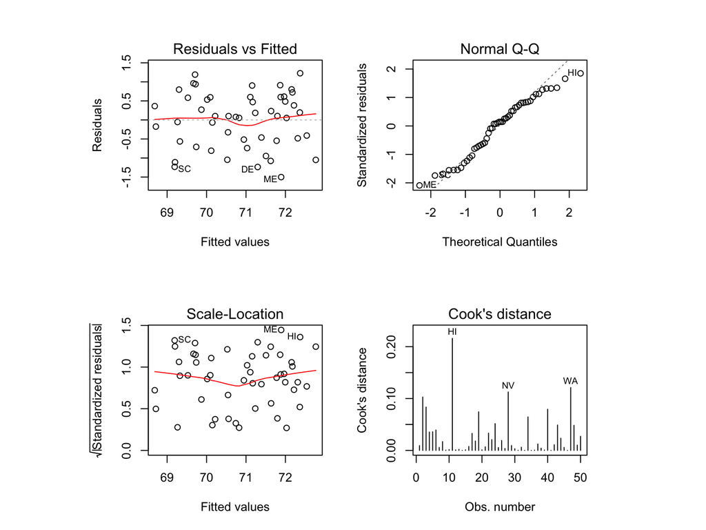

```r
life.lm = lm(Life.Exp ~ Murder + HS.Grad + Frost, data = stateEU)
layout(matrix(1:4, 2, byrow=TRUE), respect=TRUE)
plot(life.lm, which=1:4)
```

Toutes les hypothèses semblent vérifiées :

```r
stateEU[c("HI", "NV", "WA", "ME", "SC"),]
```

```
##    Population Income Illiteracy Life.Exp Murder HS.Grad Frost   Area
## HI        868   4963        1.9    73.60    6.2    61.9     0   6425
## NV        590   5149        0.5    69.03   11.5    65.2   188 109889
## WA       3559   4864        0.6    71.72    4.3    63.5    32  66570
## ME       1058   3694        0.7    70.39    2.7    54.7   161  30920
## SC       2816   3635        2.3    67.96   11.6    37.8    65  30225
```

On vérifie plus précisément l’hypothèse d’indépendance des résidus. On peut représenter l’autocorrélation des résidus

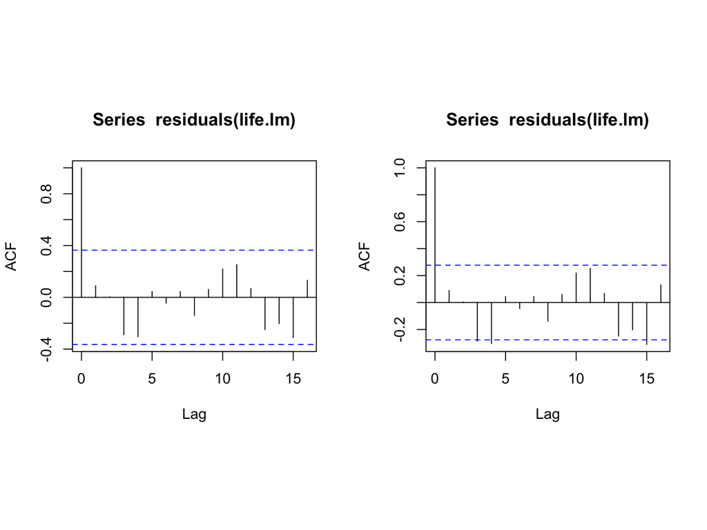

```r
layout(matrix(1:2, 1, byrow=TRUE), respect=TRUE)
acf(residuals(life.lm),ci=0.99)
acf(residuals(life.lm),ci=0.95)
```

La fonction ACF indique si la valeur actuelle dépend toujours des valeurs précédentes (les décalages = lag).

L’hypothèse d’indépendance est cohérente graphiquement, au seuil 0.99. Nous avons choisi ici d’être peu restrictifs sur l’autocorrélation en prenant un intervalle de confiance de niveau 0.99, mais elle ne serait pas valide avec une confiance de 0.95.

**Avec des tests statistiques**

-> *Shapiro test* : test de la normalité des résidus.

```r
shapiro.test(resid(life.lm))
```

```
##
##  Shapiro-Wilk normality test
##
## data:  resid(life.lm)
## W = 0.96147, p-value = 0.1024
```

-> *Rainbow test* : test de la linéarité du modèle.

```r
library(lmtest)
raintest(life.lm)
```

```
##
##  Rainbow test
##
## data:  life.lm
## Rain = 1.212, df1 = 25, df2 = 21, p-value = 0.3298
```

On obtient une p-valeur de 32.98%. On ne rejette pas le modèle linéaire. On teste ensuite l’hypothèse d’homogénéité des variances :

-> *Goldfeld-Quandt test* : test de l’homoscedasticité.

```r
gqtest(life.lm)
```

```
##
##  Goldfeld-Quandt test
##
## data:  life.lm
## GQ = 0.73553, df1 = 21, df2 = 21, p-value = 0.7562
## alternative hypothesis: variance increases from segment 1 to 2
```

On obtient une p-valeur de 75.62%. L’homogénéité de la variance des résidus n’est pas rejetée.

-> *Durbin-Watson test* : test de l’indépendance des résidus.

```r
dwtest(life.lm)
```

```
##
##  Durbin-Watson test
##
## data:  life.lm
## DW = 1.794, p-value = 0.2323
## alternative hypothesis: true autocorrelation is greater than 0
```

On obtient une p-valeur de 23.23%. L’indépendance des résidus n’est pas rejetée (Attention, le test de Durbin Wastson teste l’autocorrélation d’ordre 1 et d’autres tests peuvent être plus adaptés,le test de Box-Pierce par exemple). Nous vérifions enfin qu’il n’y a pas de colinéarité forte dans le modèle, c’est-à-dire que les variables explicatives ne sont pas linéairement dépendantes.

```r
library(car)
vif(life.lm)
```

```
##   Murder  HS.Grad    Frost
## 1.633405 1.339236 1.437903
```

Les valeurs des VIF (Variance Inflation Factors) étant inférieures à 10, les variables ne présentent pas de forte colinéarité.

## V. Test statistique et IC

### Analyse de la variance: Test de Fisher

On se pose la question de l’effet des variables $X$ :

$\mathcal{H}_0 : {\beta_1 = ... = \beta_p = 0}$

contre

$\mathcal{H}_1 : \exists$ au moins un $j$ tel que ${\beta_j \neq 0}$ où $j$ varie de $1$ à $p$.

*Remarque*: Si l’hypothèse nulle est vérifiée, alors $y_i = \beta_0 + \epsilon_i$

## V. Test statistique et IC

### Analyse de la variance: Test de Fisher

Tableau de l’analyse de la variance

| Source de variation | sc | ddl | cm | $F_{obs}$ |
| --- | --- | --- | --- | --- |
| Régression | $sc_{reg} = \sum^n_{i=1}(\widehat{y}_i - \overline{y})^2$ | p-1 | $\frac{sc_{reg}}{p-1}$ | $\frac{cm_{reg}}{cm_{res}}$ |
| Résiduelle | $sc_{res} = \sum^n_{i=1}(y_i - \widehat{y})^2$ | n-p | $\frac{sc_{reg}}{n-p}$ |  |
| Totale | $sc_{tot} = \sum^n_{i=1}(y_i - \overline{y})^2$ | n-1 |  |  |

## V. Test statistique et IC

### Test de Fisher : Méthode

1. Calculer la statistique
   $$F_{obs} = \frac{CM_{reg}} {CM_{res}}$$
2. Lire la valeur critique $F_{1−\alpha,p−1,n−p}$ où $F_{1−\alpha,p−1,n−p}$ est le $(1 − \alpha)$-quantile d’une loi de Fisher avec $(p − 1)$ et $(n − p)$ degrés de liberté, car si l’hypothèse nulle $\mathcal{H}_0$ est vraie, alors $F_{obs}$ suit une loi de Fisher avec $(p − 1)$ et $(n − p)$ degrés de liberté.
3. Comparer la statistique c’est-à-dire la valeur observée à la valeur critique.

## V. Test statistique et IC

### Test de Fisher : Règle de décision

Nous décidons de rejeter l’hypothèse nulle $\mathcal{H}_0$ et d’accepter l’hypothèse alternative $\mathcal{H}_1$, au seuil $\alpha = 5\%$, si
$$|F_{obs}| \geq F_{1−\alpha,p−1,n−p}$$

Nous décidons de ne pas rejeter l’hypothèse nulle $\mathcal{H}_0$ et donc de l’accepter si
$$|F_{obs}| < F_{1−\alpha,p−1,n−p}$$

## V. Test statistique et IC

### Test de Fisher: exemple avec R

```r
summary(life.lm)
```

```
##
## Call:
## lm(formula = Life.Exp ~ Murder + HS.Grad + Frost, data = stateEU)
##
## Residuals:
##     Min      1Q  Median      3Q     Max
## -1.5015 -0.5391  0.1014  0.5921  1.2268
##
## Coefficients:
##              Estimate Std. Error t value Pr(>|t|)
## (Intercept) 71.036379   0.983262  72.246  < 2e-16 ***
## Murder      -0.283065   0.036731  -7.706 8.04e-10 ***
## HS.Grad      0.049949   0.015201   3.286  0.00195 **
## Frost       -0.006912   0.002447  -2.824  0.00699 **
## ---
## Signif. codes:  0 '***' 0.001 '**' 0.01 '*' 0.05 '.' 0.1 ' ' 1
##
## Residual standard error: 0.7427 on 46 degrees of freedom
## Multiple R-squared:  0.7127, Adjusted R-squared:  0.6939
## F-statistic: 38.03 on 3 and 46 DF,  p-value: 1.634e-12
```

Pour lire la p valeur du test de Fisher et celles des tests de Student, il faut s’assurer auparavant que les résidus suivent une loi normale. Pour cela, vous allez réaliser un test de normalité, celui de Shapiro-Wilk avec R.

## V. Test statistique et IC/IP

### Analyse de la variance: Test de Student

On se pose la question de l’effet de la variable $x$ :

$\mathcal{H}_0 : {\beta_j = 0}$ contre $\mathcal{H}_1 : {\beta_j \neq 0}$ pour $j = 0, ..., p$

**Conditions d’applications du test** : Les variables aléatoire $\epsilon_i$ sont indépendantes et suivent la loi normale centrée et de variance $\sigma^2$.

*Test d’ajustement des résidus à une gaussienne* : Test de shapiro, Kolmogoroff-Smirnoff, QQ plot

**Statistique du test** : Si l’hypothese nulle $\mathcal{H}_0$ est vérifiée, alors la variable aléatoire $\mathcal{T}_{\widehat\beta_j,n-2} = \frac{\widehat\beta_j-0}{s_{\widehat\beta_j}}$ suit la loi de Student $\mathcal{T}(n-2)$

**Décision et conclusion du test**: La valeur critique du test, notée $c_\alpha$ est lue dans une table de la loi de Student.

- Si la valeur absolue de la valeur de la statistique calculée sur l’echantillon, notée $\mathcal{T}_{\widehat\beta_j,n-2}(obs)$ est supérieure ou égale à $c_\alpha$, alors le test est significatif. Vous rejetez $\mathcal{H}_0$ et vous décidez que $\mathcal{H}_1$ est vraie avec un risque d’erreur de première espèce $\alpha$.
- Si la valeur absolue de la valeur de la statistique calculée sur l’echantillon, notée $\mathcal{T}_{\widehat\beta_j,n-2}(obs)$ est strictement inférieure à $c_\alpha$, alors le test n’est pas significatif. Vous conservez $\mathcal{H}_0$ avec un risque d’erreur de deuxième espèce $\beta$ à évaluer.

## V. Test statistique et IC

### Test de Student: exemple avec R

```r
summary(life.lm)
```

```
##
## Call:
## lm(formula = Life.Exp ~ Murder + HS.Grad + Frost, data = stateEU)
##
## Residuals:
##     Min      1Q  Median      3Q     Max
## -1.5015 -0.5391  0.1014  0.5921  1.2268
##
## Coefficients:
##              Estimate Std. Error t value Pr(>|t|)
## (Intercept) 71.036379   0.983262  72.246  < 2e-16 ***
## Murder      -0.283065   0.036731  -7.706 8.04e-10 ***
## HS.Grad      0.049949   0.015201   3.286  0.00195 **
## Frost       -0.006912   0.002447  -2.824  0.00699 **
## ---
## Signif. codes:  0 '***' 0.001 '**' 0.01 '*' 0.05 '.' 0.1 ' ' 1
##
## Residual standard error: 0.7427 on 46 degrees of freedom
## Multiple R-squared:  0.7127, Adjusted R-squared:  0.6939
## F-statistic: 38.03 on 3 and 46 DF,  p-value: 1.634e-12
```

La p-valeur (p-value = 8.04e-10) du test de Student, associée à « Murder » étant inférieure ou égale à $\alpha = 5\%$, le test est significatif. Nous rejetons H0 et nous décidons que H1 est vraie avec un risque de première espèce $\alpha = 5\%$.

La p-valeur (p-value = 0.00195 ) du test de Student, associée à « HS.Grad » étant inférieure ou égale à $\alpha = 5\%$, le test est significatif. Nous rejetons H0 et nous décidons que H1 est vraie avec un risque de première espèce $\alpha = 5\%$.

La p-valeur (p-value = 0.00699 ) du test de Student, associée à « Frost » étant inférieure ou égale à $\alpha = 5\%$, le test est significatif. Nous rejetons H0 et nous décidons que H1 est vraie avec un risque de première espèce $\alpha = 5\%$.

## V. Test et IC

### Intervalle de confiance

On peut construire les intervalles de confiance suivants

$$IC_{1-\alpha}(\widehat\beta_j) = \Big]\widehat\beta_j - t_{n-2;1-\alpha/2}*s_{\beta_j}; \widehat\beta_j + t_{n-2;1-\alpha/2}*s_{\beta_j}\Big[$$

Cet intervalle de confiance est construit de telle sorte qu’il contienne le paramètre inconnu $\beta_j$ avec une probabilité de $(1−\alpha)$.

## V. Test et IC

### IC/IP exemples sous R

1. Intervalle de confiance

```r
confint(life.lm)
```

```
##                   2.5 %       97.5 %
## (Intercept) 69.05717472 73.015582905
## Murder      -0.35700149 -0.209128849
## HS.Grad      0.01935043  0.080546980
## Frost       -0.01183825 -0.001985219
```

```r
ci=  c(life.lm$coefficients - 1.96*summary(life.lm)$coefficients[,2], life.lm$coefficients+ 1.96*summary(life.lm)$coefficients[,2])
ci
```

```
## (Intercept)      Murder     HS.Grad       Frost (Intercept)      Murder
## 69.10918496 -0.35505856  0.02015450 -0.01170879 72.96357266 -0.21107177
##     HS.Grad       Frost
##  0.07974291 -0.00211468
```

2. Intervalle de prédiction

Supposons que nous disposions des données pour un nouveau pays, par exemple européen. Nous souhaitons comparer l’espérance de vie estimée avec ce modèle avec l’espérance de vie observée. L’intervalle de con ance sur la valeur prédite est donné par l’instruction suivante :

```r
life.pred = predict(life.lm,data.frame(Murder=8,  HS.Grad=75, Frost=80, Population=4250), interval="confidence",se.fit = TRUE)
ci=  c(life.pred$fit[1] - 1.96*life.pred$se.fit, life.pred$fit[1]+ 1.96*life.pred$se.fit)
life.pred
```

```
## $fit
##        fit      lwr     upr
## 1 71.96507 71.22295 72.7072
##
## $se.fit
## [1] 0.3686845
##
## $df
## [1] 46
##
## $residual.scale
## [1] 0.7426689
```

```r
ci
```

```
## [1] 71.24245 72.68769
```

## VI. Sélection de variables

- Critères de choix

– Critère du $R^2$

– Critère d’information d’Akaike (AIC)

– Critère d’information bayesien (BIC)

- Procédure de sélection de variable

– Forward (ou pas à pas ascendante)

– Backward (ou pas à pas descendante)

– Stepwise

## VI. Sélection de variables

### Les critères

### Pseudo-$R^2$ (Cox-Snell, Nagelkerke)

Augmente de façon monotone avec l’introduction de nouvelles variables

### Critètre d’information d’Akaike (AIC)

Le critère AIC est défini par :

$$AIC = n*log(\frac{SC_{res}}{n}) + 2(p+1)$$

### Critètre d’information bayesien (BIC)

Le critère BIC est défini par :

$$BIC = n*log(\frac{SC_{res}}{n}) + log(n)(p+1)$$

Pour l’AIC et le BIC :

- le critère s’applique aux modèles estimés par une méthode du **maximum de vraisemblance**
- le meilleur modèle est celui qui minimise le critère

Le BIC est plus parcimonieux que l’AIC puisqu’il pénalise plus le nombre de variables présentent de le modèle.

## VI. Sélection de variables

### Les méthodes

Méthodes les plus classiques:

- Forward (ou pas à pas ascendante)
- Backward (ou pas à pas descendante)
- Stepwise

Ces méthodes s’appuient sur les **données recueillies**

Elles sont **itératives**

Elle dépendent de **paramètres** (à valeur prédéfinie)

Bien que l’efficacité de ces méthodes ne puisse être démentie par la pratique, il ne serait pas raisonnable de se fier uniquement aux résultats statistiques fournis par un algorithme. En effet, pour décider d’ajouter ou de supprimer une variable dans un modèle, il faut conserver :

- une part d’intuition
- une part de déduction
- une part de synthèse

## VI. Sélection de variables

### Exemple détaillé sous R

On souhaite expliquer l’espérance de vie Life.Exp en fonction des autres variables. On va utiliser pour cela une méthode descendante.

Si nous souhaitons minimiser le critère AIC, nous pouvons l’obtenir de la façon suivante :

```r
life.lm <- lm(Life.Exp ~ ., data=stateEU)
summary(life.lm)
```

```
##
## Call:
## lm(formula = Life.Exp ~ ., data = stateEU)
##
## Residuals:
##      Min       1Q   Median       3Q      Max
## -1.48895 -0.51232 -0.02747  0.57002  1.49447
##
## Coefficients:
##               Estimate Std. Error t value Pr(>|t|)
## (Intercept)  7.094e+01  1.748e+00  40.586  < 2e-16 ***
## Population   5.180e-05  2.919e-05   1.775   0.0832 .
## Income      -2.180e-05  2.444e-04  -0.089   0.9293
## Illiteracy   3.382e-02  3.663e-01   0.092   0.9269
## Murder      -3.011e-01  4.662e-02  -6.459 8.68e-08 ***
## HS.Grad      4.893e-02  2.332e-02   2.098   0.0420 *
## Frost       -5.735e-03  3.143e-03  -1.825   0.0752 .
## Area        -7.383e-08  1.668e-06  -0.044   0.9649
## ---
## Signif. codes:  0 '***' 0.001 '**' 0.01 '*' 0.05 '.' 0.1 ' ' 1
##
## Residual standard error: 0.7448 on 42 degrees of freedom
## Multiple R-squared:  0.7362, Adjusted R-squared:  0.6922
## F-statistic: 16.74 on 7 and 42 DF,  p-value: 2.534e-10
```

```r
extractAIC(life.lm)
```

```
## [1]   8.00000 -22.18462
```

(On préférera extractAIC à la fonction AIC qui donne un critère légèrement différent.) On commence par enlever les variables dont la p-valeur est supérieure à 0.3.

```r
life.lm <-  update(life.lm,.~.-Area-Illiteracy-Income)
summary(life.lm)
```

```
##
## Call:
## lm(formula = Life.Exp ~ Population + Murder + HS.Grad + Frost,
##     data = stateEU)
##
## Residuals:
##      Min       1Q   Median       3Q      Max
## -1.47095 -0.53464 -0.03701  0.57621  1.50683
##
## Coefficients:
##               Estimate Std. Error t value Pr(>|t|)
## (Intercept)  7.103e+01  9.529e-01  74.542  < 2e-16 ***
## Population   5.014e-05  2.512e-05   1.996  0.05201 .
## Murder      -3.001e-01  3.661e-02  -8.199 1.77e-10 ***
## HS.Grad      4.658e-02  1.483e-02   3.142  0.00297 **
## Frost       -5.943e-03  2.421e-03  -2.455  0.01802 *
## ---
## Signif. codes:  0 '***' 0.001 '**' 0.01 '*' 0.05 '.' 0.1 ' ' 1
##
## Residual standard error: 0.7197 on 45 degrees of freedom
## Multiple R-squared:  0.736,  Adjusted R-squared:  0.7126
## F-statistic: 31.37 on 4 and 45 DF,  p-value: 1.696e-12
```

```r
extractAIC(life.lm)
```

```
## [1]   5.00000 -28.16123
```

On constate que l’AIC a bien diminué. On enlève ensuite la variable dont le coefficient est le moins significatif, ici Population.

```r
life.lm <-  update(life.lm,.~.-Population)
summary(life.lm)
```

```
##
## Call:
## lm(formula = Life.Exp ~ Murder + HS.Grad + Frost, data = stateEU)
##
## Residuals:
##     Min      1Q  Median      3Q     Max
## -1.5015 -0.5391  0.1014  0.5921  1.2268
##
## Coefficients:
##              Estimate Std. Error t value Pr(>|t|)
## (Intercept) 71.036379   0.983262  72.246  < 2e-16 ***
## Murder      -0.283065   0.036731  -7.706 8.04e-10 ***
## HS.Grad      0.049949   0.015201   3.286  0.00195 **
## Frost       -0.006912   0.002447  -2.824  0.00699 **
## ---
## Signif. codes:  0 '***' 0.001 '**' 0.01 '*' 0.05 '.' 0.1 ' ' 1
##
## Residual standard error: 0.7427 on 46 degrees of freedom
## Multiple R-squared:  0.7127, Adjusted R-squared:  0.6939
## F-statistic: 38.03 on 3 and 46 DF,  p-value: 1.634e-12
```

```r
extractAIC(life.lm)
```

```
## [1]   4.00000 -25.91958
```

On constate que l’AIC a augmenté (et que l’écart-type estimé des résidus a augmenté : il vaut 0.7427 contre 0.7197 auparavant). On préfère donc le modèle conservant la variable Population.

```r
life.lm <- lm(Life.Exp ~ Murder + HS.Grad + Frost + Population)
```

R peut faire ce raisonnement de manière automatisée. Il suffit d’appliquer

```r
life.lm <- step(lm(Life.Exp ~ .,data=stateEU), method="bakward")
```

```
## Start:  AIC=-22.18
## Life.Exp ~ Population + Income + Illiteracy + Murder + HS.Grad +
##     Frost + Area
##
##              Df Sum of Sq    RSS     AIC
## - Area        1    0.0011 23.298 -24.182
## - Income      1    0.0044 23.302 -24.175
## - Illiteracy  1    0.0047 23.302 -24.174
## <none>                    23.297 -22.185
## - Population  1    1.7472 25.044 -20.569
## - Frost       1    1.8466 25.144 -20.371
## - HS.Grad     1    2.4413 25.738 -19.202
## - Murder      1   23.1411 46.438  10.305
##
## Step:  AIC=-24.18
## Life.Exp ~ Population + Income + Illiteracy + Murder + HS.Grad +
##     Frost
##
##              Df Sum of Sq    RSS     AIC
## - Illiteracy  1    0.0038 23.302 -26.174
## - Income      1    0.0059 23.304 -26.170
## <none>                    23.298 -24.182
## - Population  1    1.7599 25.058 -22.541
## - Frost       1    2.0488 25.347 -21.968
## - HS.Grad     1    2.9804 26.279 -20.163
## - Murder      1   26.2721 49.570  11.569
##
## Step:  AIC=-26.17
## Life.Exp ~ Population + Income + Murder + HS.Grad + Frost
##
##              Df Sum of Sq    RSS     AIC
## - Income      1     0.006 23.308 -28.161
## <none>                    23.302 -26.174
## - Population  1     1.887 25.189 -24.280
## - Frost       1     3.037 26.339 -22.048
## - HS.Grad     1     3.495 26.797 -21.187
## - Murder      1    34.739 58.041  17.456
##
## Step:  AIC=-28.16
## Life.Exp ~ Population + Murder + HS.Grad + Frost
##
##              Df Sum of Sq    RSS     AIC
## <none>                    23.308 -28.161
## - Population  1     2.064 25.372 -25.920
## - Frost       1     3.122 26.430 -23.877
## - HS.Grad     1     5.112 28.420 -20.246
## - Murder      1    34.816 58.124  15.528
```

Le critère choisi par défaut est alors l’AIC. Il est également possible de choisir les méthodes “forward” et “both”. Ensuite on peut résumer les différentes étapes de la façon suivante :

```r
life.lm$anova
```

```
##           Step Df    Deviance Resid. Df Resid. Dev       AIC
## 1              NA          NA        42   23.29714 -22.18462
## 2       - Area  1 0.001086580        43   23.29822 -24.18229
## 3 - Illiteracy  1 0.003759832        44   23.30198 -26.17422
## 4     - Income  1 0.006058246        45   23.30804 -28.16123
```

On peut également utiliser les fonctions add1 et drop1, non détaillées ici.

## Notes

Ce cours s’inspire des références suivantes:

- Frédéric Bertrand & Myriam Maumy-Bertrand
- Franck Picard
- Irenne Ganaz